# Analysis and model building

Showing some summary graphs and statistics for the Kumeu Weather data that will be used for weather forecasting. Historical hourly weather data is available from Jan 2016 til May 2021.

Goals to achieve:

1. Predict temperature
2. Export temperature model
3. Repeat steps 1 and 2 with variables: rainfall, humidity, windspeed

Task list:

- ✓ Import historic data
- ✓ Plot graphs to view data
- ✓ Format and export historic data as csv
- ✓ Format and export historic data as DataFrame (in pickle format)
- ✓ Encode and standardise data to prepare for model training
- ✓ Export standardised model data as csv and DataFrame (pickle format)
- ✓ Build model
- To do: Tune model parameters
- To do: Train model
- To do: Evaluate model
- **At this stage, the model is ready to be exported as an initial proof of concept for the prediction app**
- To do: Build, train and evaluate models with different architectures for model selection
- To do: Hyper-parameter tuning to improve the selected model
- To do: Critically analyse the strengths and weaknesses of the model and predictions
- To do: Repeat all steps for the variables: rainfall, humidity, wind-speed

## Preliminaries: Install and import necessary libraries

If running this notebook for the first time, you will need to install all the libraries with the code below. This only needs to be done once.

```python
%%capture
# Install and import libraries. %%capture is used to suppress messages for library install statuses

import sys

!{sys.executable} -m pip install -r requirements.txt
```

Import all the libraries required for this notebook to run.

```python
import os, random, csv, re, datetime
import pandas as pd
import numpy as np
import matplotlib
import scipy.optimize as opt
import plotly.express as px
import plotly.offline as pyo
import tensorflow as tf
from tqdm import tqdm
from sklearn.preprocessing import StandardScaler, MaxAbsScaler, MinMaxScaler
from sklearn.preprocessing import OneHotEncoder
from sklearn.model_selection import train_test_split, TimeSeriesSplit
from tensorflow.keras import Sequential
from tensorflow.keras.layers import Dense, Dropout, LSTM, Embedding, Activation, RepeatVector, TimeDistributed
from xgboost import XGBRegressor
from tensorflow.keras.optimizers import Adam, RMSprop

# Suppress Tensorflow warning messages
os.environ['TF_CPP_MIN_LOG_LEVEL'] = '3'  # or any {'0', '1', '2'}

# displays full numbers in dataframes instead of scientific notation for clarity
pd.set_option('float_format', '{:f}'.format)
pd.set_option('display.max_columns', 500)

# For model building/training
tf.config.experimental_run_functions_eagerly(True)
```

## Import historic hourly Kumeu weather data

The hourly data is given as multiple CSV files. The file paths are listed below.

```python
data_dir = "../data/Weather Station Hourly/"

input_data_paths = [data_dir+"MetWatch Export (20{}).csv".format(i) for i in range(16,22)]
input_data_paths
```

```
['../data/Weather Station Hourly/MetWatch Export (2016).csv',
 '../data/Weather Station Hourly/MetWatch Export (2017).csv',
 '../data/Weather Station Hourly/MetWatch Export (2018).csv',
 '../data/Weather Station Hourly/MetWatch Export (2019).csv',
 '../data/Weather Station Hourly/MetWatch Export (2020).csv',
 '../data/Weather Station Hourly/MetWatch Export (2021).csv']
```

The hourly weather data from the CSV files is imported into memory, ready for processing.

```python
input_data = []

for data_path in input_data_paths:
    csv_list = []
    with open(data_path) as f:
        next(f)
        next(f)
        for line in f.readlines():
            if ',' in line:
                input_data.append(line.strip().split(','))

for i in range(len(input_data)):
    if len(input_data[i])<2:
        input_data[i] = None
        continue
    else:
        date_split = input_data[i][0].split(' ')[1:]
        date_split[0] = re.sub('[a-zA-Z]+','',date_split[0])
        date_split[-1] = date_split[-1].strip('"')
        input_data[i][0] = " ".join(date_split)
        if len(input_data[i])>1:
            input_data[i][1] = input_data[i][1].strip('"')
            input_data[i][8] = input_data[i][8].strip('"')
        for j in range(1,len(input_data[i])):
            if input_data[i][j] == '':
                input_data[i][j] = None
            elif input_data[i][j] == '-':
                input_data[i][j] = None
```

## Preprocessing

The hourly weather data is created as a Pandas Data Frame, Column names, column types and null values are tidied up. The dates are converted to DateTime objects (day, month, year, hour) so that they can be easily processed later. A sample of this pre-processed data is printed below.

```python
raw_df = pd.DataFrame(data=input_data, columns=['date','time_hourly','temp_C','rain_mm','wetness_percent','rel_humidity_percent',
                                 'wind_speed_kmph','wind_direction','spray_drift_risk','backup_data','missing_data'])

raw_df = raw_df.astype(dtype={'date':'object','time_hourly':'object','temp_C':'float64','rain_mm':'float64',
                                  'wetness_percent':'float64','rel_humidity_percent':'float64',
                                  'wind_speed_kmph':'float64','wind_direction':'object','spray_drift_risk':'object',
                                  'backup_data':'float64','missing_data':'object'})
```

```python
raw_df['max_hour_str'] = raw_df['time_hourly'].str.split('-').str[-1].str.strip()
raw_df['datetime_mid']= pd.to_datetime(raw_df['date'] + raw_df['max_hour_str'], format='%d %b %Y%I%p') - pd.Timedelta(minutes=30)
raw_df['end_hour'] = pd.to_datetime(raw_df['max_hour_str'], format='%I%p').dt.hour
raw_df['start_hour'] = raw_df['end_hour'] - 1
raw_df.loc[raw_df['start_hour']==-1, 'start_hour'] = 23
raw_df['day'] = raw_df['datetime_mid'].dt.day
raw_df['month'] = raw_df['datetime_mid'].dt.month
raw_df['year'] = raw_df['datetime_mid'].dt.year

train_df = raw_df[['datetime_mid','temp_C','rain_mm','wetness_percent','rel_humidity_percent','wind_speed_kmph','wind_direction','spray_drift_risk','backup_data','missing_data','year','month','day','start_hour','end_hour']]
train_df = train_df.set_index('datetime_mid')
train_df.sample(2)
```

| datetime_mid | temp_C | rain_mm | wetness_percent | rel_humidity_percent | wind_speed_kmph | wind_direction | spray_drift_risk | backup_data | missing_data | year | month | day | start_hour | end_hour |
| --- | --- | --- | --- | --- | --- | --- | --- | --- | --- | --- | --- | --- | --- | --- |
| 2017-06-12 04:30:00 | 6.800000 | 0.000000 | 98.500000 | 100.000000 | 0.200000 | S | Not Recommended | NaN | None | 2017 | 6 | 12 | 4 | 5 |
| 2016-03-07 03:30:00 | NaN | NaN | NaN | NaN | NaN | None | None | NaN | All | 2016 | 3 | 7 | 3 | 4 |

## Handling missing values

There are around 8% missing values in the dataset (approx. 3,500 out of the 46,825 hourly records). Most of the missing data is found in Jan - May 2016. The missing data values are filled in two ways:

1. If there is 1 missing value, neighboured by two filled values in the previous and next record (hour), then the record is filled by copying the previous hour's value.
2. If there is more than 1 missing value in a row (more than 1 consecutive hour of data missing), then these values are filled using an average value. These values are calculated as the average value for that hour, day and month across the entire dataset (2016-2021).

```python
# If there is a gap of just 1 record, then fill it with the previously observed value
train_df.fillna(method='ffill', inplace=True, limit=1)
```

```python
# Calculating the average weather measurements for each month, day and hour across the entire dataset (2016-2021)
month_day_hour_avg = train_df.groupby(["month","day","start_hour","end_hour"]).aggregate(np.mean)
month_day_hour_avg
```

| month | day | start_hour | end_hour | temp_C | rain_mm | wetness_percent | rel_humidity_percent | wind_speed_kmph | backup_data | year |
| --- | --- | --- | --- | --- | --- | --- | --- | --- | --- | --- |
| 1 | 1 | 0 | 1 | 15.060000 | 0.000000 | 81.040000 | 94.180000 | 0.920000 | NaN | 2018.500000 |
|  |  | 1 | 2 | 14.320000 | 0.000000 | 87.240000 | 95.260000 | 0.300000 | NaN | 2018.500000 |
|  |  | 2 | 3 | 13.900000 | 0.000000 | 82.180000 | 96.140000 | 0.540000 | NaN | 2018.500000 |
|  |  | 3 | 4 | 13.540000 | 0.000000 | 79.680000 | 96.600000 | 0.480000 | NaN | 2018.500000 |
|  |  | 4 | 5 | 13.020000 | 0.000000 | 74.980000 | 96.740000 | 0.700000 | NaN | 2018.500000 |
| ... | ... | ... | ... | ... | ... | ... | ... | ... | ... | ... |
| 12 | 30 | 20 | 21 | 17.520000 | 0.000000 | 13.580000 | 77.780000 | 7.200000 | NaN | 2018.000000 |
|  |  | 21 | 22 | 15.960000 | 0.000000 | 31.900000 | 84.920000 | 3.320000 | NaN | 2018.000000 |
|  |  | 22 | 23 | 14.640000 | 0.000000 | 76.940000 | 89.760000 | 2.060000 | NaN | 2018.000000 |
|  | 31 | 0 | 1 | 13.580000 | 0.000000 | 76.860000 | 93.480000 | 1.980000 | NaN | 2018.000000 |
|  |  | 23 | 0 | 16.940000 | 0.000000 | 75.820000 | 92.200000 | 1.300000 | NaN | 2017.500000 |

8761 rows × 7 columns

```python
# Fill all other missing values with the average values across entire dataset

columns = ['temp_C','rain_mm','wetness_percent','rel_humidity_percent','wind_speed_kmph']
for index, row in train_df.iterrows():
    if row.isna().sum()== 0:
        continue
    for column in columns:
        if np.isnan(row[column]):
            month, day, start_hour, end_hour = row['month'], row['day'], row['start_hour'], row['end_hour']
            train_df.loc[index, column] = month_day_hour_avg.loc[month, day, start_hour, end_hour][column]
```

Now that the null values have been processed, the table below shows the resulting number of null values in the datset. The weather attributes that have 0 null values have been fully filled in: temperature, rainfall, wetness, relative humidity and windspeed.

```python
train_df.isnull().sum()
```

```
temp_C                      0
rain_mm                     0
wetness_percent             0
rel_humidity_percent        0
wind_speed_kmph             0
wind_direction           3452
spray_drift_risk         3882
backup_data             46825
missing_data            42898
year                        0
month                       0
day                         0
start_hour                  0
end_hour                    0
dtype: int64
```

## Checkpoint: save data (optional)

The input weather data is now formatted. Output as csv and pickle file. The pickle file (.pkl) is a copy of the pre-processed DataFrame so you don't need to repeat the steps above.

```python
train_df.to_csv('../data/hourly_2016_2021.csv')
train_df.to_pickle('../data/hourly_2016_2021.pkl')
```

## Checkpoint: load raw train dataset (optional)

You can run the code below to start the notebook from this point. This saves time as you won't need to run any of the processing steps above.

```python
train_df = pd.read_pickle('../data/hourly_2016_2021.pkl')
```

## Graphs

Visual graph of temperature data. Data appears seasonal a high level (year and month level). Seasonality patterns are not as strong, and there are some irregularities when looking at temperature on the granular hourly level.

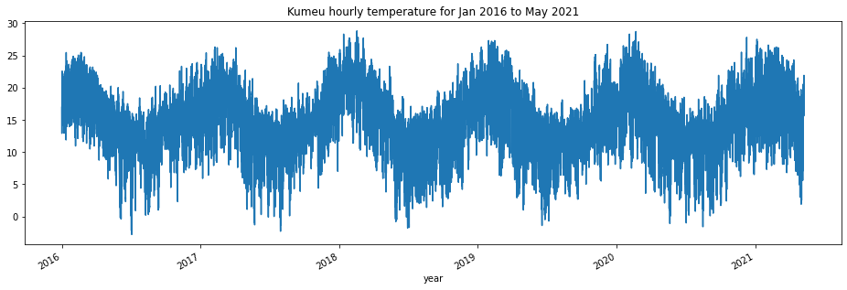

```python
total_temp_plot = train_df['temp_C'].plot(figsize=(16,5),title='Kumeu hourly temperature for Jan 2016 to May 2021',xlabel='year')
```

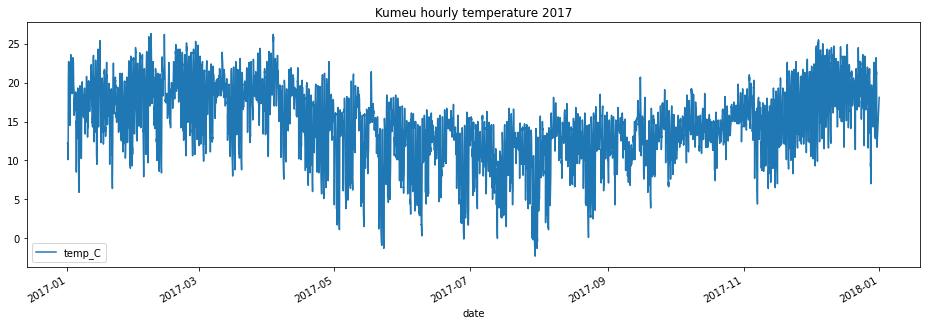

```python
temp_2017 = train_df[['temp_C']].loc[train_df.index.year==2017].plot(figsize=(16,5),title='Kumeu hourly temperature 2017',xlabel='date')
```

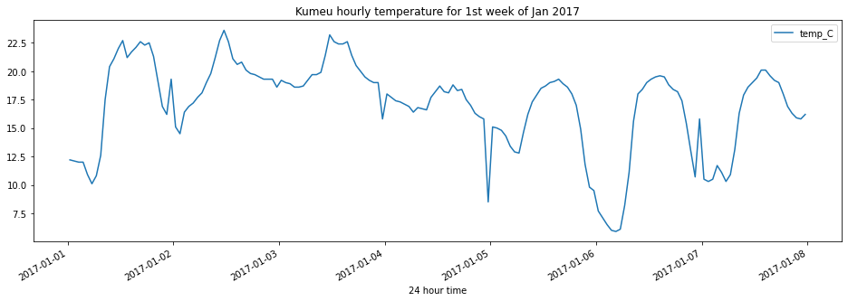

```python
temp_1week = train_df[['temp_C']].loc[(train_df.index.year==2017) & (train_df.index.month==1) & (train_df.index.day<8)].plot(figsize=(16,5),title='Kumeu hourly temperature for 1st week of Jan 2017',xlabel='24 hour time')
```

[figure not shown]

```python
temp_1week = train_df[['temp_C']].loc[(train_df.index.year==2018) & (train_df.index.month==1) & (train_df.index.day==1)].plot(figsize=(16,5),title='Kumeu hourly temperature for 1st week of Jan 2018',xlabel='24 hour time', grid=True)
```

## Preparing data for model training

The data needs to be transformed before it can be input into a neural network model. The following steps are taken in this section:

- One Hot Encoding
- Normalisation

```python
train_df.drop(labels=['year','month','day','start_hour','end_hour','backup_data','spray_drift_risk','missing_data'], axis=1, inplace=True)

train_df_encoded = pd.get_dummies(train_df, drop_first=True)
#put temperature at the end of the dataframe because that will be the label - the value we are trying to predict
train_df_encoded = train_df_encoded[['rain_mm','wetness_percent','rel_humidity_percent','wind_speed_kmph',
                                    'wind_direction_N','wind_direction_NE','wind_direction_NW','wind_direction_S',
                                    'wind_direction_SE','wind_direction_SW','wind_direction_W','temp_C']]
```

This is what the data looks like after performing One Hot Encoding. This affects Wind Direction only as it is the only categorical column only. For each row, all wind direction columns are 0 except for 1, which represents the correct wind direction category for that row.

```python
train_df_encoded.sample(5)
```

| datetime_mid | rain_mm | wetness_percent | rel_humidity_percent | wind_speed_kmph | wind_direction_N | wind_direction_NE | wind_direction_NW | wind_direction_S | wind_direction_SE | wind_direction_SW | wind_direction_W | temp_C |
| --- | --- | --- | --- | --- | --- | --- | --- | --- | --- | --- | --- | --- |
| 2016-08-31 11:30:00 | 0.000000 | 0.100000 | 68.300000 | 3.400000 | 0 | 0 | 0 | 1 | 0 | 0 | 0 | 16.000000 |
| 2019-05-10 02:30:00 | 0.000000 | 84.700000 | 98.700000 | 0.000000 | 0 | 0 | 0 | 0 | 0 | 0 | 1 | 12.100000 |
| 2016-11-30 01:30:00 | 0.000000 | 80.100000 | 72.700000 | 4.500000 | 0 | 0 | 0 | 0 | 0 | 1 | 0 | 15.300000 |
| 2020-12-29 10:30:00 | 0.000000 | 0.200000 | 55.600000 | 17.400000 | 0 | 0 | 0 | 0 | 0 | 1 | 0 | 18.900000 |
| 2017-03-31 11:30:00 | 0.000000 | 0.200000 | 73.900000 | 1.900000 | 0 | 0 | 0 | 1 | 0 | 0 | 0 | 20.300000 |

```python
#train_df_encoded_scaled = pd.DataFrame(StandardScaler().fit_transform(train_df_encoded))

scaler = MinMaxScaler(feature_range=(-1,1))
scaler = scaler.fit(train_df_encoded)
train_df_encoded_scaled = pd.DataFrame(scaler.transform(train_df_encoded))
```

Here is what the data looks like after performing Min-Max scaling normalisation. The data ranges for all columns is -1 to 1. The data column names have also disappeared and are just numbers as this is required for model input.

```python
train_df_encoded_scaled.sample(5)
```

|  | 0 | 1 | 2 | 3 | 4 | 5 | 6 | 7 | 8 | 9 | 10 | 11 |
| --- | --- | --- | --- | --- | --- | --- | --- | --- | --- | --- | --- | --- |
| 20405 | -1.000000 | -0.770000 | 0.795022 | -0.971671 | -1.000000 | -1.000000 | -1.000000 | -1.000000 | -1.000000 | 1.000000 | -1.000000 | 0.126582 |
| 12388 | -1.000000 | 0.944000 | 1.000000 | -1.000000 | 1.000000 | -1.000000 | -1.000000 | -1.000000 | -1.000000 | -1.000000 | -1.000000 | -0.405063 |
| 3116 | -1.000000 | 0.476000 | 0.834261 | -0.972805 | -1.000000 | -1.000000 | -1.000000 | -1.000000 | -1.000000 | -1.000000 | -1.000000 | 0.039241 |
| 21543 | -1.000000 | -0.996000 | 0.285505 | -0.399433 | -1.000000 | -1.000000 | -1.000000 | -1.000000 | -1.000000 | -1.000000 | 1.000000 | 0.253165 |
| 36840 | -1.000000 | 0.926000 | 0.923865 | -1.000000 | 1.000000 | -1.000000 | -1.000000 | -1.000000 | -1.000000 | -1.000000 | -1.000000 | -0.424051 |

## Checkpoint: save data (optional)

The input data is now formatted for neural network implementation. The data is saved as a csv file and also a pickle file. The pickle file can be loaded directly into a Python script so that you can skip all the above steps and start working directly with the data formatted for model implementation.

Code to import pickle file: `pd.read_pickle(file path to the pickle file)`

```python
train_df_encoded_scaled.to_csv('../data/hourly_2016_2021_encoded_scaled.csv')
train_df_encoded_scaled.to_pickle('../data/hourly_2016_2021_encoded_scaled.pkl')
```

## Checkpoint: load data (optional)

You can run the code below to start the notebook from this point. This saves time as you won't need to run any of the processing steps above.

```python
train_df_encoded_scaled = pd.read_pickle('../data/hourly_2016_2021_encoded_scaled.pkl')
```

## Data conversion

Now the data will be converted from DataFrame object to Numpy array because this format is required for model input.

```python
# Only train on temperature, humidity and wind speed
#train_df_encoded_scaled =train_df_encoded_scaled[[11,2,3]]
train_df_encoded_scaled = train_df_encoded_scaled.to_numpy()
train_df_encoded_scaled.shape
#train_df_encoded_scaled
```

```
(46825, 12)
```

## Zaytar and Amrani model (2016)

There was a paper written in 2016 by Zaytar and Amrani where a neural network was built to create hourly weather forecasts for the variables: rainfall, temperature and humidity. I have decided to recreate this model's architecture to see if it is suitable for forecasts for our dataset. Below is a diagram of this model's architecture:

[figure not shown]

Source: Zaytar, M. A., & El Amrani, C. (2016). Sequence to sequence weather forecasting with long short-term memory recurrent neural networks. International Journal of Computer Applications, 143(11), 7-11.

## Train/test data split

```python
# As required for LSTM networks, we require to reshape an input data into n_samples x timesteps x n_features.
trainX = []
trainY = []

n_future = 24  # Number of days we want to predict into the future
n_past = 168  # Number of past days we want to use to predict the future

for i in range(n_past, len(train_df_encoded_scaled) - n_future +1):
    trainX.append(train_df_encoded_scaled[i - n_past:i, 0:train_df_encoded_scaled.shape[1]])
    trainY.append(train_df_encoded_scaled[i:i + n_future, 0:train_df_encoded_scaled.shape[1]])
    #trainY.append(train_df_encoded_scaled[i + n_future - 1:i + n_future, -1])

trainX, trainY = np.array(trainX), np.array(trainY)

print('trainX shape: {}.'.format(trainX.shape))
print('trainY shape: {}.'.format(trainY.shape))
```

```
trainX shape: (46634, 168, 12).
trainY shape: (46634, 24, 12).
```

## Build model

Building and compiling the model from Zaytar and Amrani (2016). The RMSprop formula is used as the optimisation function and mean square error (mse) is used as the loss function - this is consistent with the authors' implementation.

```python
# LSTM architecture from Zaytar and Amrani (2016), modified to fit our dataset
from tensorflow.keras.optimizers import Adam, RMSprop
model = Sequential(name='zaytar_amrani_2016')

model.add(LSTM(trainX.shape[2], activation='relu', input_shape=(trainX.shape[1], trainX.shape[2]), return_sequences=True, name = 'lstm1'))
model.add(LSTM(100, activation='relu', return_sequences=False, name='lstm2'))
model.add(Dense(100, name='dense'))
model.add(Activation(activation='relu', name='activation'))
model.add(RepeatVector(n=24, name = 'repeat'))
model.add(LSTM(100, activation='relu', return_sequences=True, name='lstm3'))
model.add(LSTM(100, activation='relu', return_sequences=True, name='lstm4'))
model.add(TimeDistributed(Dense(trainX.shape[2]), name='timedistributed'))
#model.add(Dense(trainY.shape[1], name = "dense2"))

#model.compile(optimizer='adam', loss='mse')


opt = RMSprop(learning_rate=0.0001)
model.compile(loss='mse', optimizer=opt)

model.summary()
```

```
Model: "zaytar_amrani_2016"
_________________________________________________________________
Layer (type)                 Output Shape              Param #
=================================================================
lstm1 (LSTM)                 (None, 168, 12)           1200
_________________________________________________________________
lstm2 (LSTM)                 (None, 100)               45200
_________________________________________________________________
dense (Dense)                (None, 100)               10100
_________________________________________________________________
activation (Activation)      (None, 100)               0
_________________________________________________________________
repeat (RepeatVector)        (None, 24, 100)           0
_________________________________________________________________
lstm3 (LSTM)                 (None, 24, 100)           80400
_________________________________________________________________
lstm4 (LSTM)                 (None, 24, 100)           80400
_________________________________________________________________
timedistributed (TimeDistrib (None, 24, 12)            1212
=================================================================
Total params: 218,512
Trainable params: 218,512
Non-trainable params: 0
_________________________________________________________________
```

- Removing wind data from the model
- Using different learning rates
- Using different batch sizes

```python
# Train the model.
history = model.fit(trainX, trainY,
                    epochs=20, batch_size=128,
                    validation_split=0.1,
                    verbose=1)
```

[output not shown]

[output cut: 144 more lines]

[output not shown]

## Ignore below

Below is code that is work in progress - ignore for now.

## Train model

```python
# define Autoencoder model

model = Sequential(name='lstm')

model.add(LSTM(trainX.shape[2], activation='relu', input_shape=(trainX.shape[1], trainX.shape[2]), return_sequences=True, name = 'lstm1'))
model.add(LSTM(100, activation='relu', return_sequences=False, name='lstm2'))
model.add(Dense(100, name='dense'))
model.add(Activation(activation='relu', name='activation'))
model.add(RepeatVector(n=24, name = 'repeat'))
model.add(LSTM(100, activation='relu', return_sequences=True, name='lstm3'))
model.add(TimeDistributed(Dense(trainX.shape[2]), name='timedistributed'))

model.compile(optimizer='adam', loss='mse')


opt = Adam(learning_rate=0.001)
model.compile(loss='categorical_crossentropy', optimizer=opt)

model.summary()
```

[output not shown]

```python
# Example LSTM - this is just an example from Sreenivas Bhattiprolu's example. It was not designed to forecast weather
# define Autoencoder model

# model = Sequential()
# model.add(LSTM(64, activation='relu', input_shape=(trainX.shape[1], trainX.shape[2]), return_sequences=True))
# model.add(LSTM(32, activation='relu', return_sequences=False))
# model.add(Dropout(0.2))
# model.add(Dense(trainY.shape[1]))

# model.compile(optimizer='adam', loss='mse')
# model.summary()
```

```python
from sklearn.model_selection import TimeSeriesSplit
tscv = TimeSeriesSplit(n_splits=24, max_train_size=72, test_size=12)
print(tscv)
```

```python
# fit model
history = model.fit(trainX, trainY,
                    epochs=3,batch_size=64,
                    validation_data=0.1,
                    verbose=1)
```

```python
trainX = []
trainY = []

for train_index, test_index in tscv.split(train_df_encoded_scaled):
    print("TRAIN:", train_index, "TEST:", test_index)
    trainX.append(train_df_encoded_scaled[train_index])
    trainY.append(train_df_encoded_scaled[test_index])
    #X_train, X_test = trainX[train_index], trainX[test_index]
    #y_train, y_test = trainY[train_index], trainY[test_index]
```